# Does a Pitcher Care About His Earned Run Average?

Kevin Ferris

2015-04-12

# 1 Introduction

Baseball fans, players, and analysts go to the park hoping to see their team win (Keri and Prospectus 2007). But they do not abandon their allegiances to their team the moment they leave the ballpark. They continue to discuss the game, team, and players in offices, bars, households, and blogs across the country.

These discussions vary from favorite players to in-game tactical decisions with heated arguments developing on even decisions in single at bats. Another popular discussion topic is attempting to determine how much each individual player contributed to the team’s success or failure. But assigning the credit or blame is difficult because all the players on the team were working together to achieve the win. So fans and analysts, create statistics which summarize the individual contributions from each player.

These statistics date back to the very beginning of baseball when Henry Chadwick produced the first box score recording the statistics of batters and pitchers for individual games (Schiff 2008). Since then, statistics have been continually introduced into baseball as fans and analysts try to find more precise ways of acknowledging a player’s contribution. In the 1970’s, an analyst named Bill James started closely examining these statistics to see which were most important. This resulted in the rise of “sabermetrics” — using quantitative analysis to improve baseball statistics and decision making. This movement was championed by the early 2000s Oakland Athletics who became the most well known example of a team successfully incorporating analytics into their decision making (Lewis 2004). Because of this sabermetric revolution, it is fair to say that baseball fans, analysts, and players have never had access to the number or quality of statistics as we have access to today.

The potential problem with all these different statistics is that they attempt to discern individual performance from a group result. If the incentives are not properly aligned, then these statistics could be encouraging players to take actions that are not beneficial to the team. For example, it may be beneficial for an outfielder to attempt a risky diving catch, while the team might prefer that play it safe and not take such risky behavior. From the outfielder’s point of view, his diving catch could be shown on ESPN’s Web Gems segment or may otherwise catch the attention of people who would not remember him safely letting a ball drop. The fundamental objective of this paper is to examine whether one of the commonly used statistics presents an incentive for baseball pitchers that is not beneficial from the team’s point of view.

## 1.1 Explanation

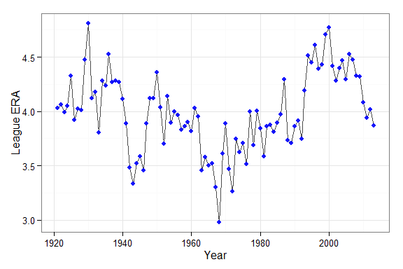

The strange thing about this statistic is that only accounts for batters who scored *that a pitcher is responsible for* rather than all batters who the pitcher faces. A pitcher is deemed “not responsible” for a batter if, for example, a fielder makes an error and allows the runner to reach base. Because it is not the pitcher’s fault that the runner reached base (due to the fielding error), the theory behind ERA is that the pitcher should not be penalized if that runner scores.

However, this creates a potential problem with the incentives present for the pitcher: because ERA is one of the primary tools used to evaluate pitchers, in the situations when ERA does not apply the incentives are not as strong.

We theorize that pitchers may pitch differently when ERA applies (when the pitcher is responsible for the runners) than when it does not. Specifically, we believe that when a pitcher is not responsible for the men on base, he will be more likely to pitch in “dangerous locations” — over the middle of the plate where batters are easily able to hit the ball. Conversely, when a pitcher is responsible for the men on base, he will be somewhat more likely to pitch around the edges of the strike zone where batters have more difficulty.

# 2 Data

## 2.1 Raw

Starting in the 2006 playoffs, Major League Baseball began using pitch tracking cameras to record information about each pitch thrown in a game. By 2008, these cameras were implemented in every ball park in the majors. These cameras track velocity, movement, release point, spin, and pitch location at the moment each pitch enters the strike zone. MLB’s Gameday API provides these data (known as PITCHF/x data) for free in an XML format [online](http://gd2.mlb.com/components/game/mlb/). They also provide additional data such as balls, strikes, outs, and runners on base. For more information on the data provided by PITCHf/x, see (Fast 2010).

For example, on May 10, 2013 Jon Lester struck out Adam Lind with an 88 mph cut fastball to end the game. The pitch was located low and inside on the left-handed Lind. The video can be found [here](http://m.mlb.com/video/?content_id=27002963&topic_id=6479266). Using the coordinates provided by the PITCHF/x data, the location of the pitch when it enters the strike zone can be plotted (see plot below).

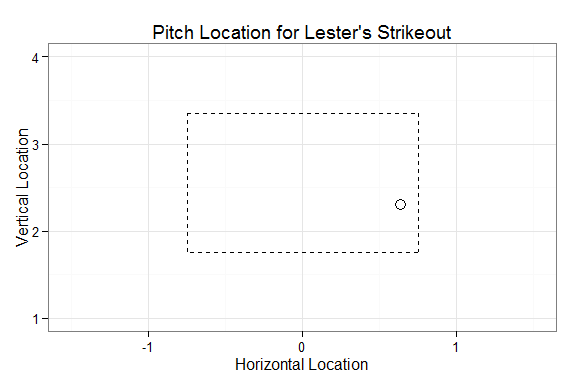

Using the `pitchRx` R package (C. Sievert and Sievert 2014), the regular season PITCHF/x data from 2014 were downloaded in April, 2015.

## 2.2 Cleaned

The question of interest for this project is whether baseball pitchers pitch differently when they are responsible for the runners on base. I began by extracting all the pitches thrown when runners were on base. Therefore, in the data, each observation is a single pitch that occurred when there was at least one runner on base.

In 2014, there were 126572 of these pitches. For each observation, I recorded whether the pitcher was responsible for the men on base. In situations where there were multiple men on base and the pitcher was responsible for some but not all of them, the pitcher was deemed responsible.

1. batter reaches on a hit or otherwise after his time at bat is prolonged by a muffed foul fly. This cannot be determined from PITCHF/x. It is a very infrequent event so I chose to ignore these occurrences.
2. batter reaches because of interference or obstruction
3. batter reaches because of any fielding error
4. the inning is prolonged because of a fielding error
5. a relief pitcher inherits runners on base

This resulted in 117766 pitches where the pitcher was responsible and 8806 pitches where the pitcher was not responsible. A small portion of the data set is presented below.

```
Source: local data frame [126,572 x 8]

                     gameday_link num id    px   pz resp_pit p_throws
1  gid_2014_03_30_lanmlb_sdnmlb_1   5 38 2.077 2.56     resp        L
2  gid_2014_03_30_lanmlb_sdnmlb_1   5 39 1.100 2.85     resp        L
3  gid_2014_03_30_lanmlb_sdnmlb_1   5 41 1.331 2.76     resp        L
4  gid_2014_03_30_lanmlb_sdnmlb_1   5 44 0.712 2.74     resp        L
5  gid_2014_03_30_lanmlb_sdnmlb_1   6 51 1.608 2.62     resp        L
6  gid_2014_03_30_lanmlb_sdnmlb_1   6 52 0.629 3.10     resp        L
7  gid_2014_03_30_lanmlb_sdnmlb_1   6 53 0.908 2.39     resp        L
8  gid_2014_03_30_lanmlb_sdnmlb_1   6 54 0.222 3.58     resp        L
9  gid_2014_03_30_lanmlb_sdnmlb_1   7 58 2.099 2.91     resp        L
10 gid_2014_03_30_lanmlb_sdnmlb_1   7 59 2.112 3.42     resp        L
..                            ... ... ..   ...  ...      ...      ...
Variables not shown: stand (chr)
```

In baseball, there are both left-handed and right-handed batters and left-handed and right-handed pitchers. Pitch locations differ for each of these handedness combinations (see plot below). It appears that pitchers like to stay away from batters regardless of the pitcher’s throwing hand. Visually, there appear to be only slight differences between the locations of pitches thrown by left and right handed pitchers. While these differences are slight, there are substantial differences in mindset and approach between left and right handed pitchers. Due to these differences, the data were separated into four different pairs of handedness.

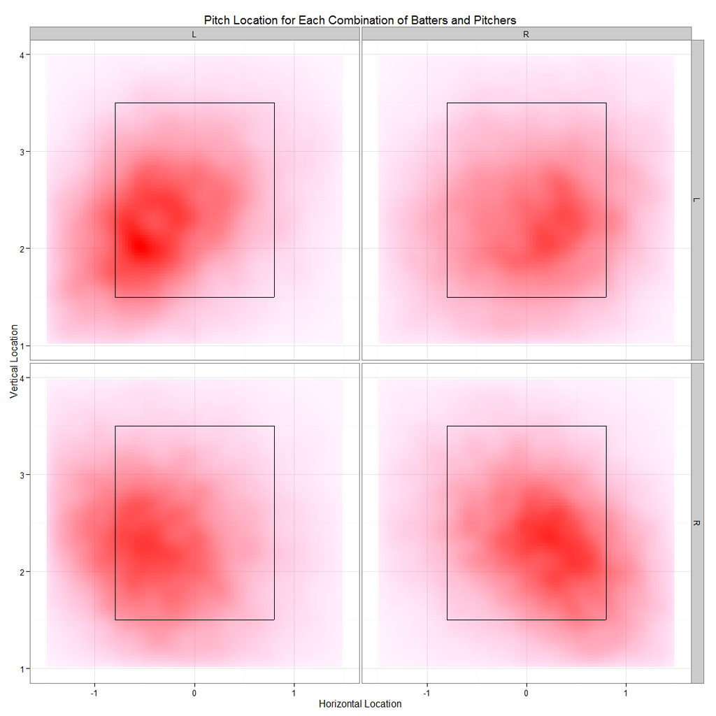

To simplify the analysis for this writing project, only pitches thrown by left-handed pitchers to left-handed batters were considered. This handedness combination was chosen for two reasons. It is the most infrequent combination so it presented the smallest and easiest data set to analyze. It was also the handedness pair that provide the most suggestive results during early exploration so most of the effort was put into understanding these data. Data were cleaned using the `dplyr` R package (Wickham and Francois 2014).

# 3 Methodology

## 3.1 How to Test the Idea

The plot below shows a 2d kernel density estimate of pitch location in 2014 for left handed pitchers vs left handed batters. This estimate is made by constructing a two dimensional $n \times n$ grid of the strike zone where $n$ represents the number of grid points. At each grid point, the pitch density (i.e. the relative likelihood that a pitch is thrown in this location) is calculated for each of these grid points.

In one dimension, the density for a single point ($x$) is calculated by taking a weighted average of the density of points near $x$. By weighting points near $x$ more heavily, densities will be larger if there are more points near $x$. For more details, see (Higgins 2004). This process extends to two dimensions by taking a weighted average of the density of points in to dimensions, rather than just one. Density estimates were obtained using the `MASS` package in R (Venables and Ripley 2002).

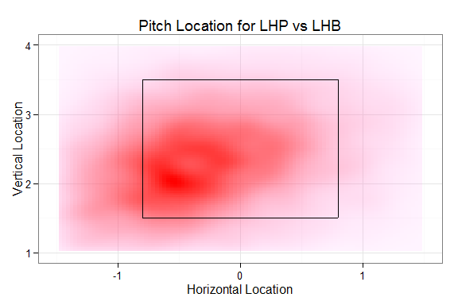

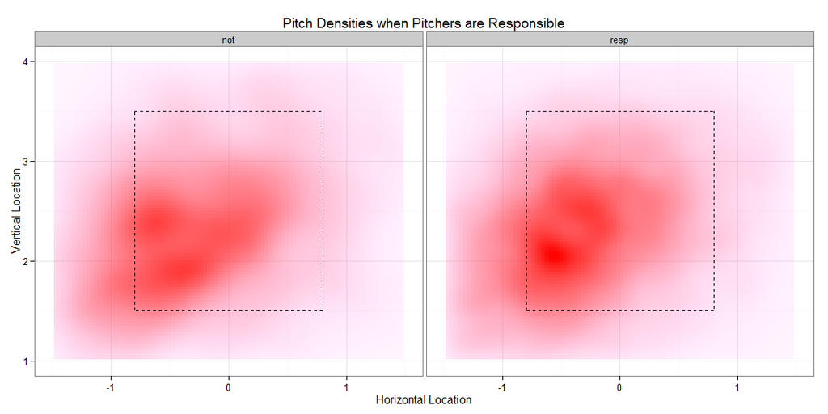

Two visualizations of the differences in densities are plotted below. Both show that the surface is not very flat, but there are no strong patterns immediately obvious. One trend that is interesting is that from the top-middle of the strikezone, there seems to be a constant trend of large, negative differences that runs diagonally towards the middle-outer part of the strikezone. This is a very strange result that could potentially be interesting.

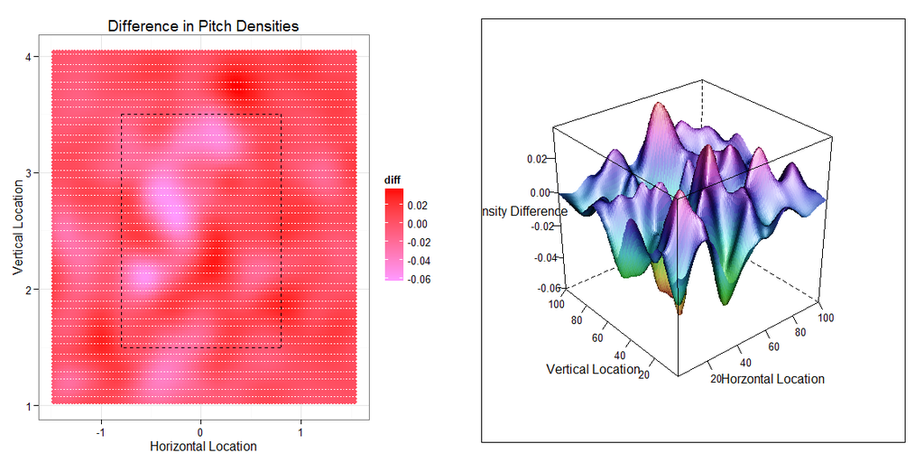